# Michigan PFAS Data

## Description

From the state of Michigan’s website:

*PFAS are a large group of man-made chemicals that include perfluorooctanoic acid (PFOA) and perfluorooctanesulfonic acid (PFOS). PFAS have been used globally during the past century in manufacturing, firefighting and thousands of common household and other consumer products. These chemicals are persistent in the environment and in the human body – meaning they don’t break down and they can accumulate over time. In recent years, experts have become increasingly concerned by the potential effects of high concentrations of PFAS on human health.*

PFAS contamination in West Michigan has unfortunately made [headlines](https://www.wzzm13.com/article/news/local/judge-approves-54m-settlement-kent-co-residents-wolverine-3m-pfas-case/69-091ea42c-125a-4341-8ea0-238fdac4d06e), reminiscent of other environmental advocacy efforts like that of renowned whistleblower [Erin Brockovich](https://en.wikipedia.org/wiki/Erin_Brockovich).

There are multiple PFAS-related data sets available from the state of Michigan contained in a single zipped file on [GitHub](https://github.com/dilernia/STA418-518/blob/main/Data/pfas_data.zip) https://github.com/dilernia/STA418-518/blob/main/Data/pfas_data.zip:

1. **Surface water sampling data**; PFAS concentrations in surface water samples 🏞🐟
2. **Public water supply sampling data**; PFAS concentrations in municipal drinking water samples 💧🫗
3. **PFAS sites data** ; PFAS contamination or investigation sites of interest ☢️🏭

The original data dictionary for the full surface water data is available at https://gis-egle.hub.arcgis.com/datasets/egle::pfas-surface-water-sampling/about.

A non-comprehensive laboratory PFAS analyte list (showing for example that PFTeDA is Perfluorotetradecanoic acid) for analyzing data collected by Michigan’s Departments of Environment, Great Lakes, and Energy (EGLE), Health and Human Services (HHS), Agriculture and Rural Development, and Natural Resources can be found [here](https://www.michigan.gov/pfasresponse/-/media/Project/Websites/PFAS-Response/Sampling-Guidance/Minimum-Laboratory-Analyte-List.pdf?rev=a35aba56ec5a4922b986f01e25c1a19d&hash=04E6F164AA5F5CD29B83B39983341345): https://www.michigan.gov/pfasresponse/-/media/Project/Websites/PFAS-Response/Sampling-Guidance/Minimum-Laboratory-Analyte-List.pdf?rev=a35aba56ec5a4922b986f01e25c1a19d&hash=04E6F164AA5F5CD29B83B39983341345.

## Source

Data was obtained from the state of Michigan website https://gis-egle.hub.arcgis.com/search?q=pfasgis.

## Data Dictionary

### Surface water sampling data

| Variable | Description |
| --- | --- |
| geoid | geographic region ID with the first 2 digits being the state Federal Information Processing Standard (FIPS) code and the last 3 digits the county FIPS code |
| longitude | The longitude coordinate for the sampling location |
| latitude | The latitude coordinate for the sampling location |
| lab_sample_id | The sample ID provided by the analytical laboratory |
| site_code | The sampling location name |
| coc_sample_id | The sample ID listed on chain of custody provided to the analytical laboratory |
| sample_type | An expanded description of what type of sample was collected |
| lab_name | The name of the analytical laboratory used for analysis of the sample |
| lab_job_name | The analytical laboratories job/work order name |
| collection_date | The date that the sample was collected |
| analysis_method | The analysis method used by the analytical laboratory to analyze the sample |
| dilution_factor | The dilution factor used by the analytical laboratory during sample preparation |
| analysis_date | The date that the analysis was conducted by the analytical laboratory |
| duplicate | A description of what type of sample was collected |
| watershed | The watershed that the sample was collected from |
| waterbody | The waterbody the sample was collected from |
| location_code | The sampling location code |
| huc10 | The 10 digit hydrological unit code for the sampling location |
| huc8 | The 8 digit hydrological unit code for the sampling location |
| project | The project that is associated with the sampling |
| description | A description of the sampling location |
| additional_description | An additional description of the sampling location |
| visit_id | The identification number of the sampling event |
| sample_depth | An expanded description of the sampling depth |
| analyte | PFAS analyte |
| analyte_value | The analyte concentration in the sample measured in parts per trillion (ppt or ng/L) |

### Public water supply sampling data

From the [EGLE website](https://www.michigan.gov/egle/maps-data/mpart-pfas-gis):

*The public water supply results include information from both the State of Michigan funded drinking water Per- and Polyfluoroalkyl Substances (PFAS) sampling effort, and ongoing PFAS compliance monitoring of public water supplies in Michigan. It includes, but is not limited to, sample location, sample date, and sample results…*

*The combined public water supply results data is representative of the PFAS sampling locations, with each location having multiple samples taken, dates for each sample, and the analytical results for each sample.*

| Variable | Description |
| --- | --- |
| geoid | geographic region ID with the first 2 digits being the state Federal Information Processing Standard (FIPS) code and the last 3 digits the county FIPS code |
| longitude | The longitude coordinate for the sampling location |
| latitude | The latitude coordinate for the sampling location |
| system_name | Name of water supply system |
| system_type | Type of water supply system |
| sample_date | The date that the sample was collected |
| lab_name_code | Code for processing lab |
| analyte | PFAS analyte |
| analyte_value | The analyte concentration in the sample measured in parts per trillion (ppt or ng/L) |

### PFAS sites

This data was last updated on 02/05/2025, and was downloaded on 02/25/2025 from the [EGLE](https://gis-egle.hub.arcgis.com/maps/17b26cf283624bf49705741e81fde0c4) website. Cleaned data in a more convenient CSV format is available [here](https://raw.githubusercontent.com/dilernia/STA418-518/refs/heads/main/Data/pfas_sites.csv): https://raw.githubusercontent.com/dilernia/STA418-518/refs/heads/main/Data/pfas_sites.csv. From the EGLE website:

*The Michigan PFAS Sites layer is the official list of PFAS sites in Michigan. This data is updated as new PFAS sites are encountered.*

The original website for the definitions of the site variables is [here](https://gis-egle.hub.arcgis.com/datasets/egle::michigan-pfas-sites/about): https://gis-egle.hub.arcgis.com/datasets/egle::michigan-pfas-sites/about.

| Variable | Type | Description |
| --- | --- | --- |
| geoid | double | Geographic region ID with the first 2 digits being the state Federal Information Processing Standard (FIPS) code and the last 3 digits the county FIPS code |
| longitude | double | Longitude coordinate of sample location |
| latitude | double | Latitude coordinate of sample location |
| facility | character | Name of the site |
| county | character | County where the site is located |
| address | character | Physical address of the project site |
| city | character | City where the project is physically located |
| zip_code | double | Zip code where the project is physically located |
| type | character | Describes the kind of site by type |
| residential_wells_sampled | character | Indicates whether residential wells have, or will be sampled (Domains = Yes, No, TBD, N/A) |
| site_lead | character | Name of contact person |
| site_lead_email | character | Contact person email |
| site_lead_phone | character | Contact person phone number |
| hyperlink | character | Web address to the site investigation summary |
| location | character | Geographic location description of the site |
| military | character | Indicates if the site is associated with the military |
| facility_date | character | Date the site was published on the Michigan PFAS Action Response Team website |
| site_background | character | Background information about the site |
| drinking_water_information | character | Information about drinking water quality and safety |
| anticipated_activities | character | The state of Michigan's planned or upcoming activities related to the site |

Data summary

| Name | surface_water_long |
| --- | --- |
| Number of rows | 208548 |
| Number of columns | 26 |
| _______________________ |  |
| Column type frequency: |  |
| character | 20 |
| numeric | 6 |
| ________________________ |  |
| Group variables | None |

**Variable type: character**

| skim_variable | n_missing | complete_rate | min | max | empty | n_unique | whitespace |
| --- | --- | --- | --- | --- | --- | --- | --- |
| geoid | 3024 | 0.99 | 5 | 5 | 0 | 70 | 0 |
| lab_sample_id | 108 | 1.00 | 6 | 12 | 0 | 1797 | 0 |
| site_code | 0 | 1.00 | 9 | 13 | 0 | 1349 | 0 |
| coc_sample_id | 7344 | 0.96 | 1 | 26 | 0 | 1537 | 0 |
| sample_type | 186624 | 0.11 | 6 | 16 | 0 | 5 | 0 |
| lab_name | 0 | 1.00 | 4 | 25 | 0 | 17 | 0 |
| lab_job_name | 16308 | 0.92 | 7 | 12 | 0 | 166 | 0 |
| collection_date | 0 | 1.00 | 22 | 22 | 0 | 198 | 0 |
| analysis_method | 108 | 1.00 | 4 | 29 | 0 | 10 | 0 |
| analysis_date | 25596 | 0.88 | 22 | 22 | 0 | 216 | 0 |
| watershed | 0 | 1.00 | 4 | 21 | 0 | 52 | 0 |
| waterbody | 108 | 1.00 | 5 | 31 | 0 | 589 | 0 |
| location_code | 0 | 1.00 | 6 | 10 | 0 | 1205 | 0 |
| huc10 | 21708 | 0.90 | 9 | 10 | 0 | 153 | 0 |
| huc8 | 0 | 1.00 | 8 | 8 | 0 | 55 | 0 |
| project | 0 | 1.00 | 4 | 13 | 0 | 2 | 0 |
| description | 216 | 1.00 | 2 | 53 | 0 | 1241 | 0 |
| additional_description | 121824 | 0.42 | 5 | 69 | 0 | 413 | 0 |
| sample_depth | 206712 | 0.01 | 6 | 10 | 0 | 3 | 0 |
| analyte | 0 | 1.00 | 14 | 25 | 0 | 108 | 0 |

**Variable type: numeric**

| skim_variable | n_missing | complete_rate | mean | sd | p0 | p25 | p50 | p75 | p100 | hist |
| --- | --- | --- | --- | --- | --- | --- | --- | --- | --- | --- |
| longitude | 0 | 1.00 | -84.86 | 1.75 | -90.18 | -85.85 | -84.46 | -83.54 | -82.43 | ▁▂▃▅▇ |
| latitude | 0 | 1.00 | 43.60 | 1.57 | 41.76 | 42.47 | 43.02 | 44.42 | 47.47 | ▇▆▁▂▂ |
| dilution_factor | 16416 | 0.92 | 1.32 | 3.36 | 0.00 | 1.00 | 1.00 | 1.00 | 100.00 | ▇▁▁▁▁ |
| duplicate | 0 | 1.00 | 1.11 | 0.34 | 1.00 | 1.00 | 1.00 | 1.00 | 3.00 | ▇▁▁▁▁ |
| visit_id | 24516 | 0.88 | 2019889.60 | 1729.85 | 2013001.00 | 2019005.00 | 2020206.00 | 2021213.00 | 2022021.00 | ▁▁▃▇▇ |
| analyte_value | 53414 | 0.74 | 3.42 | 59.55 | 0.10 | 0.81 | 1.17 | 2.00 | 11000.00 | ▇▁▁▁▁ |

Data summary

| Name | public_water_long |
| --- | --- |
| Number of rows | 451052 |
| Number of columns | 9 |
| _______________________ |  |
| Column type frequency: |  |
| character | 5 |
| factor | 1 |
| numeric | 3 |
| ________________________ |  |
| Group variables | None |

**Variable type: character**

| skim_variable | n_missing | complete_rate | min | max | empty | n_unique | whitespace |
| --- | --- | --- | --- | --- | --- | --- | --- |
| geoid | 23072 | 0.95 | 5 | 5 | 0 | 87 | 0 |
| system_name | 7672 | 0.98 | 3 | 59 | 0 | 4727 | 0 |
| sample_date | 0 | 1.00 | 22 | 22 | 0 | 3623 | 0 |
| lab_name_code | 0 | 1.00 | 3 | 40 | 0 | 43 | 0 |
| analyte | 0 | 1.00 | 4 | 11 | 0 | 28 | 0 |

**Variable type: factor**

| skim_variable | n_missing | complete_rate | ordered | n_unique | top_counts |
| --- | --- | --- | --- | --- | --- |
| system_type | 0 | 1 | FALSE | 12 | Com: 394016, Sch: 20860, Non: 10752, Non: 9716 |

**Variable type: numeric**

| skim_variable | n_missing | complete_rate | mean | sd | p0 | p25 | p50 | p75 | p100 | hist |
| --- | --- | --- | --- | --- | --- | --- | --- | --- | --- | --- |
| longitude | 0 | 1.00 | -84.87 | 1.26 | -90.17 | -85.67 | -84.88 | -83.78 | -82.38 | ▁▁▆▇▆ |
| latitude | 0 | 1.00 | 43.37 | 1.24 | 41.72 | 42.48 | 42.96 | 44.05 | 47.47 | ▇▅▂▂▁ |
| analyte_value | 350273 | 0.22 | 0.49 | 7.12 | 0.00 | 0.00 | 0.00 | 0.00 | 860.00 | ▇▁▁▁▁ |

Data summary

| Name | pfas_sites |
| --- | --- |
| Number of rows | 300 |
| Number of columns | 20 |
| _______________________ |  |
| Column type frequency: |  |
| character | 16 |
| numeric | 4 |
| ________________________ |  |
| Group variables | None |

**Variable type: character**

| skim_variable | n_missing | complete_rate | min | max | empty | n_unique | whitespace |
| --- | --- | --- | --- | --- | --- | --- | --- |
| facility | 0 | 1.00 | 9 | 103 | 0 | 300 | 0 |
| county | 0 | 1.00 | 10 | 26 | 0 | 76 | 0 |
| address | 1 | 1.00 | 4 | 88 | 0 | 299 | 0 |
| city | 1 | 1.00 | 4 | 29 | 0 | 174 | 0 |
| type | 0 | 1.00 | 7 | 22 | 0 | 15 | 0 |
| residential_wells_sampled | 0 | 1.00 | 2 | 3 | 0 | 4 | 0 |
| site_lead | 0 | 1.00 | 9 | 65 | 0 | 107 | 0 |
| site_lead_email | 0 | 1.00 | 15 | 27 | 0 | 128 | 0 |
| site_lead_phone | 0 | 1.00 | 12 | 16 | 0 | 105 | 0 |
| hyperlink | 0 | 1.00 | 84 | 134 | 0 | 293 | 0 |
| location | 115 | 0.62 | 4 | 25 | 0 | 128 | 0 |
| military | 0 | 1.00 | 2 | 4 | 0 | 3 | 0 |
| facility_date | 8 | 0.97 | 22 | 22 | 0 | 190 | 0 |
| site_background | 265 | 0.12 | 626 | 3752 | 0 | 35 | 0 |
| drinking_water_information | 265 | 0.12 | 95 | 2098 | 0 | 35 | 0 |
| anticipated_activities | 265 | 0.12 | 15 | 397 | 0 | 35 | 0 |

**Variable type: numeric**

| skim_variable | n_missing | complete_rate | mean | sd | p0 | p25 | p50 | p75 | p100 | hist |
| --- | --- | --- | --- | --- | --- | --- | --- | --- | --- | --- |
| geoid | 0 | 1 | 26088.58 | 45.84 | 26001.00 | 26049.00 | 26081.00 | 26125.00 | 26163.00 | ▃▅▇▆▆ |
| longitude | 0 | 1 | -84.82 | 1.32 | -90.13 | -85.70 | -84.76 | -83.66 | -82.44 | ▁▁▇▅▇ |
| latitude | 0 | 1 | 43.24 | 1.12 | 41.78 | 42.48 | 42.95 | 43.54 | 47.46 | ▇▆▂▁▁ |
| zip_code | 0 | 1 | 49003.64 | 3935.16 | 20020.00 | 48453.50 | 48911.00 | 49442.25 | 94105.00 | ▁▇▁▁▁ |

Exploring Missingness in data sets and Exploartory Data Analysis

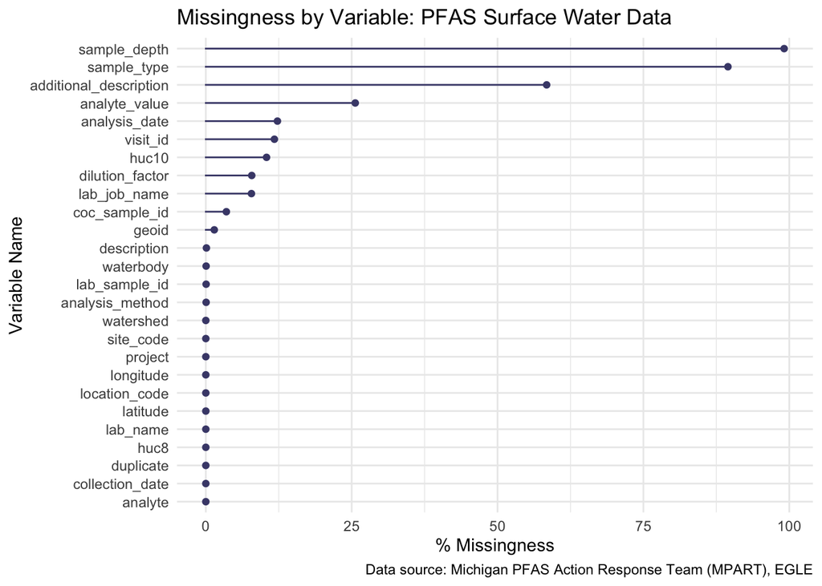

[figure not shown]

[figure not shown]

Exploratory Data Analysis

*Surface Water Analysis*

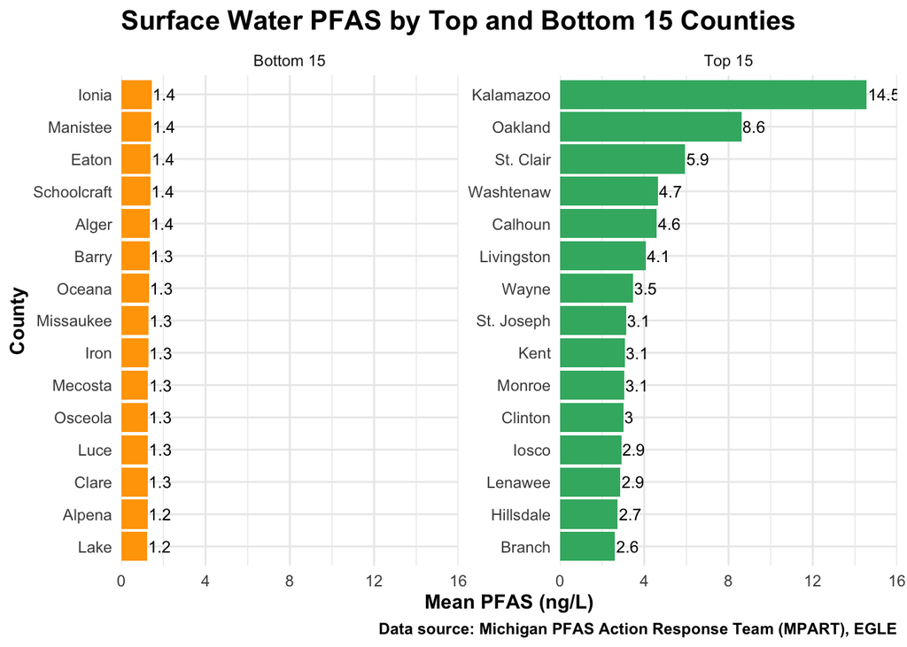

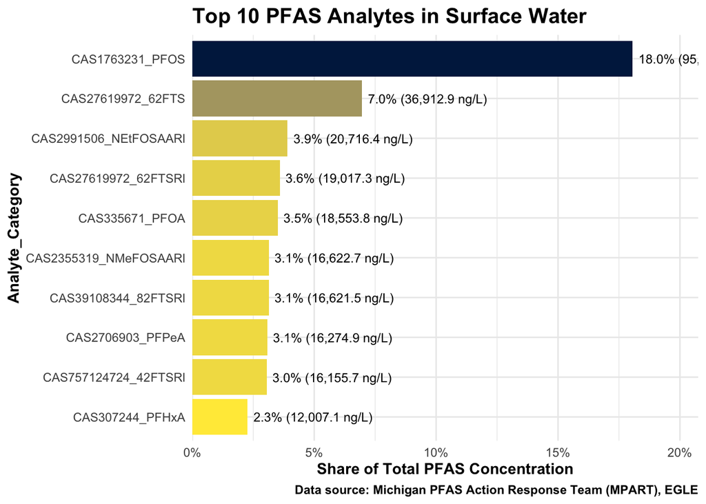

[figure not shown]

*Public Water Analysis*

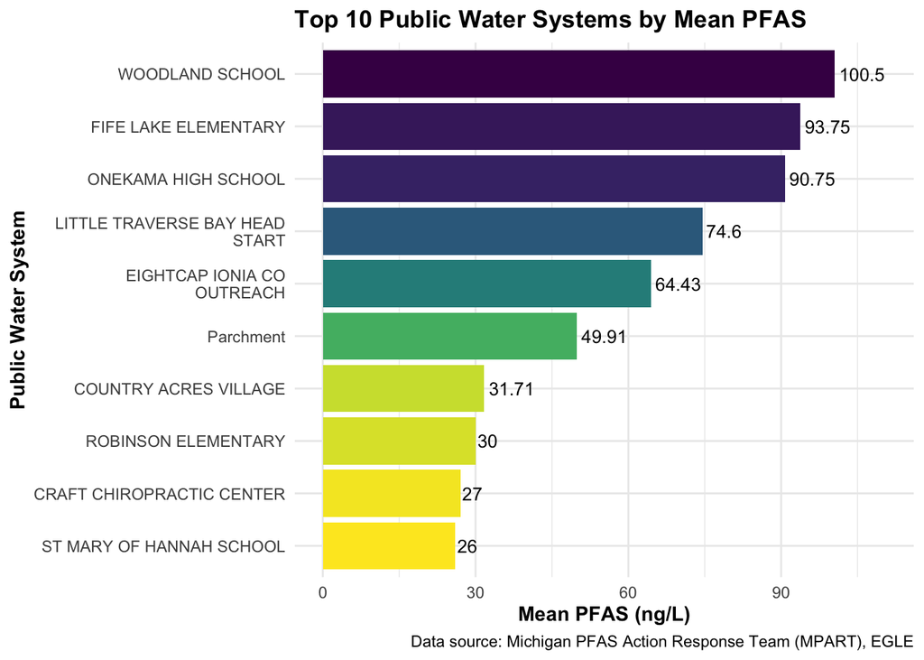

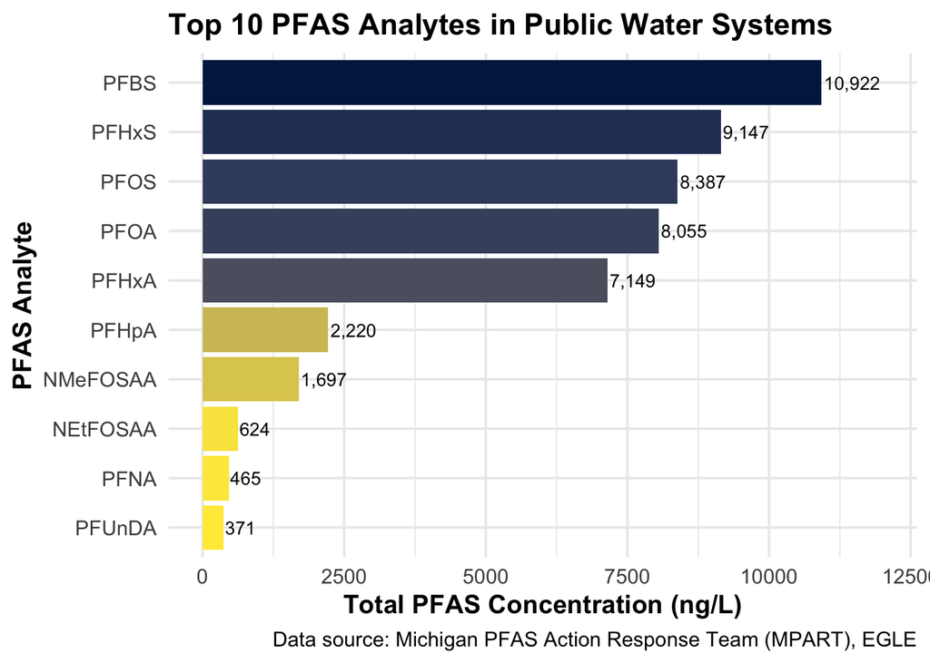

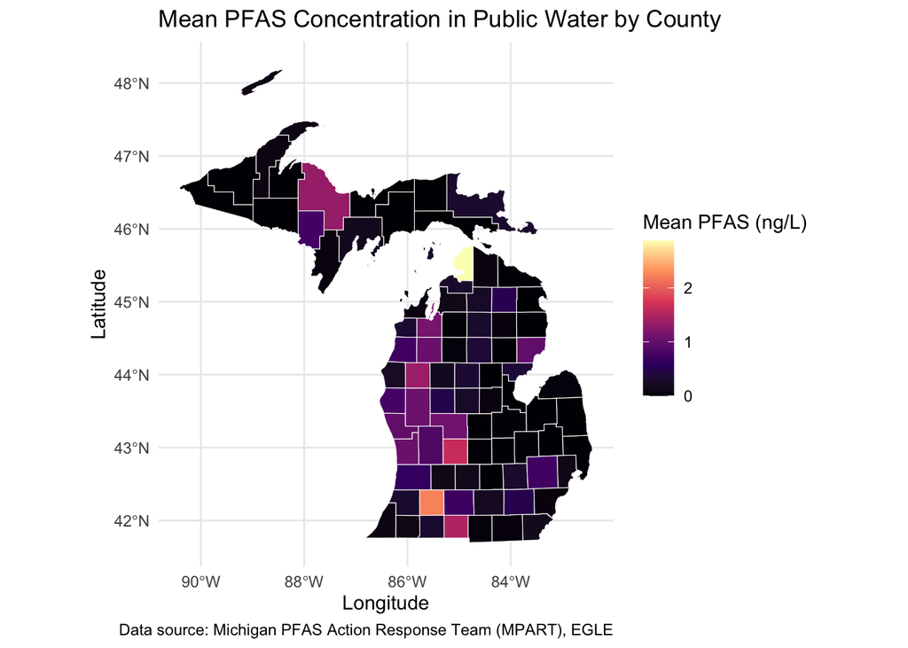

*PFAS sites Analysis*

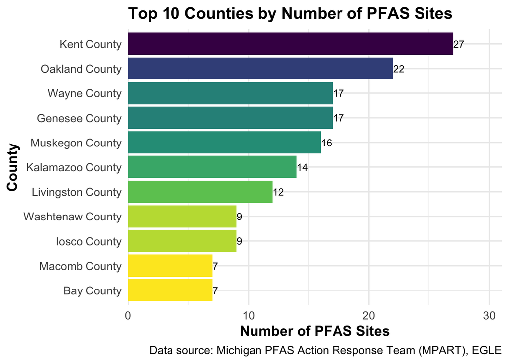

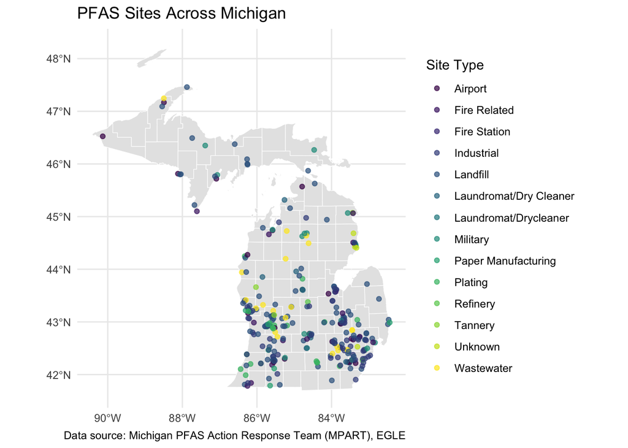

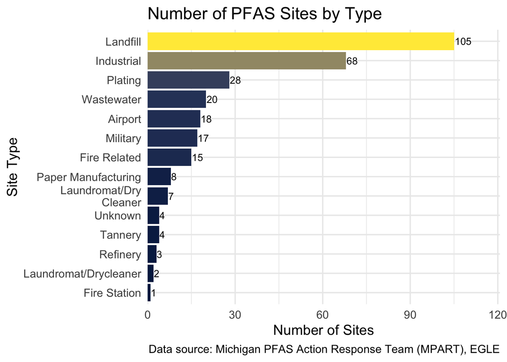

*Combined Exploratory Data Analysis*

| NAME | mean_surface | n_surface_samples | mean_public | n_public_samples | n_sites |
| --- | --- | --- | --- | --- | --- |
| Kalamazoo | 14.547086 | 6,048 | 2.230267053 | 14,700 | 14 |
| Oakland | 8.612578 | 13,716 | 0.721992730 | 33,460 | 23 |
| St. Clair | 5.945079 | 16,848 | 0.003729797 | 5,124 | 3 |
| Washtenaw | 4.659366 | 5,292 | 0.498325581 | 11,284 | 9 |
| Calhoun | 4.601994 | 3,672 | 0.702272727 | 5,936 | 2 |
| Livingston | 4.084704 | 4,320 | 0.295306389 | 23,660 | 12 |
| Wayne | 3.466084 | 14,904 | 0.046705998 | 5,152 | 18 |
| St. Joseph | 3.136617 | 3,240 | 0.314000000 | 7,140 | 4 |
| Kent | 3.072492 | 8,964 | 0.849830967 | 18,060 | 27 |
| Monroe | 3.057532 | 2,376 | 0.165734266 | 3,136 | 1 |

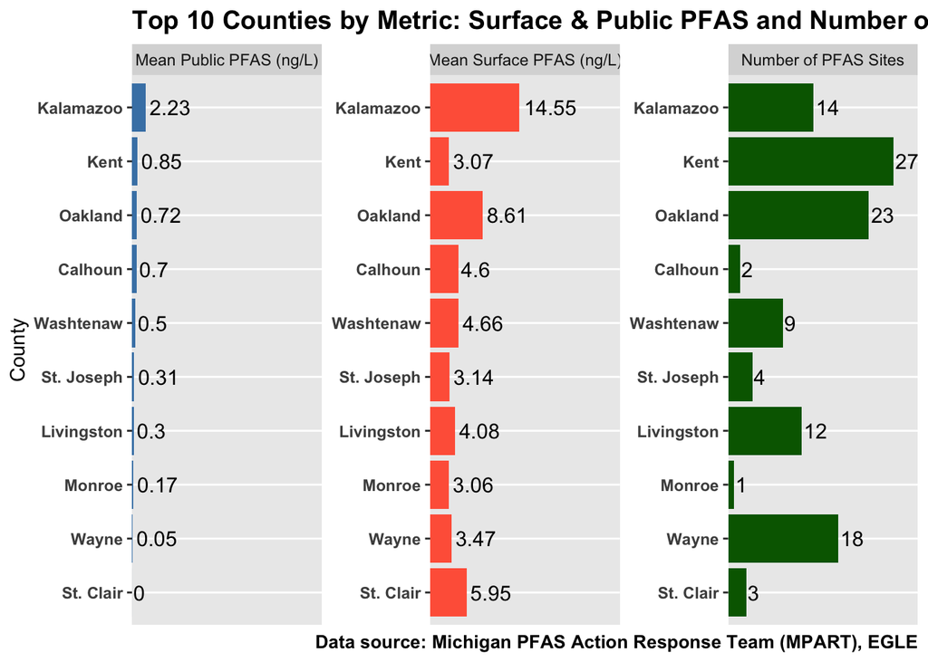